# James Soronnadi STA 512 Project

Regression Analysis on Conventional and Social Media 2014 and 2015 dataset

### Abstract

Using regression analysis on the “CSM (Conventional and Social Media Movies) 2014 and 2015 dataset”, this study delves into the complex relationship between conventional and social media factors in predicting a movie’s success. By examining variables such as Genre, Budget, Number of Screens, Sequel status, Rating, and Aggregate Actor Followers, the research aims to equip producers with the information needed to strategically allocate resources. The insights gained from this analysis can inform decisions on budgeting for social media advertising, optimizing marketing efforts, and ultimately contribute to the overall economic success of movies. By bridging the gap between data-driven analysis and practical applications, this study provides valuable tools for decision-making amidst the constantly evolving landscape of the film industry.

### Introduction

- I obtained this dataset, “CSM (Conventional and Social Media Movies) 2014 and 2015 dataset” from UC Irvine Machine Learning Repository. Here’s a link to the dataset: ‘http://archive.ics.uci.edu/static/public/424/csm+conventional+and+social+media+movies+dataset+2014+and+2015.zip’
- The original dataset was obtained by Mehreen Ahmed from the National University of Sciences and Technology, Islamabad, Pakistan (Ahmed et al., 2015) from Youtube, Twitter, and IMDB.
- The data mostly represents popular movies mostly Hollywood movies.
- The original data set was obtained to prove that social media features can predict the success of movies and even with a blend of conventional features we can predict more accurately the success of movies.
- The data was collected from various sources, including movie websites like IMDB, general web resources like Wikipedia, and social media platforms such as YouTube and Twitter. To capture dynamic data like follower counts on Twitter and ratings on IMDB, the project uses sentiment analysis libraries and regularly collects the latest data using APIs and scrapers, bypassing the use of pre-existing movie datasets. (Ahmed et al., 2015)

### Data Characteristics

The Data set comprises 231 movies with 15 variables. The variables are further described below.

### Variables

**Response**

- Gross: Total amount of money a movie makes before deductions. This is a numerical variable.

**Predictors**

1. Genre: 19 categories of Genre were considered such as Action, Adventure and Drama etc. Each nominal value of genre was mapped onto numeric value ranging from 1-19 in order to improve the performance of the learning algorithms. This is a categorical variable.
2. Budget: This numerical variable represents the production cost of movies.
3. Number of Screens: Total count of cinema screens showing a movie. It indicates how widely shown and popular a movie is. This is also a numerical variable.
4. Sequel: The value represents whether the movie is sequel or an individual. It is a numeric number that ranges from 1 to N. 1 shows that movie is first release (no sequel), whereas 2 represents that the movie is 2nd in a sequel; E.g. Pirates of Caribbean: Dead Man’s Chest is 2nd in sequel, therefore it is assigned the value of 2.This is a numerical variable.
5. Rating: The value of Ratings ranges between 1 to 10 with 1 being lowest and 10 the highest. These values are collected from IMDB. This is numerical variable.
6. Aggregate Actor Followers: Number of followers of top 3 cast. This is numerical variable.
7. Number of views: Number of views of the Trailer on youtube.This is numerical variable.
8. Number of likes: Number of likes of the Trailer on youtube.This is numerical variable.
9. Number of dislikes: Number of Dislikes of the Trailer on youtube.This is numerical variable.
10. Number of comments: Number of comments of the Trailer on youtube.This is numerical variable.
11. Sentiment Score: This feature is represented by signed integer value. 0 represents neutral sentiment, “+”sign shows the positive sentiment whereas number shows the magnitude. Similarly “–”sign shows negative sentiment. This is numerical variable.
12. Year: Movie Production Year. This is a categorical variable.

We then factor the Categorical variables.

### Prior Theories

1. Positive relationship between Numbers of Screen and Gross; The more cinema screens showing the movie the more income the movie rakes in.
2. Positive relationship between Budget and Gross, If a lot of money is spent producing a movie, it is likely going to blow up and many people will pay to see.
3. Genre is not statistically significant. The genre of a movie should not be important in determining how much a movie makes. Top movies are not from a particular genre, they could be romantic or adventurous.
4. Aggregate actor followers should not be significant in predicting Gross. So many movies have made a lot of income while casting actors who were not so popular on social media.
5. Dislikes should have a negative relationship with Gross. That is if many people dislike a movie then should it not make a lot of income, rather it should have a negative effect on Gross income.

### Exploratory Data Analysis

Firstly, we use scatter plots to view all our predictors and how they relate with the response predictors. We also plot a histogram of some of our variables. We couldn’t use a scatter plot matrix because our predictors are too much and it would not be readable. Hence, we plot our predictors individually against our response variable.

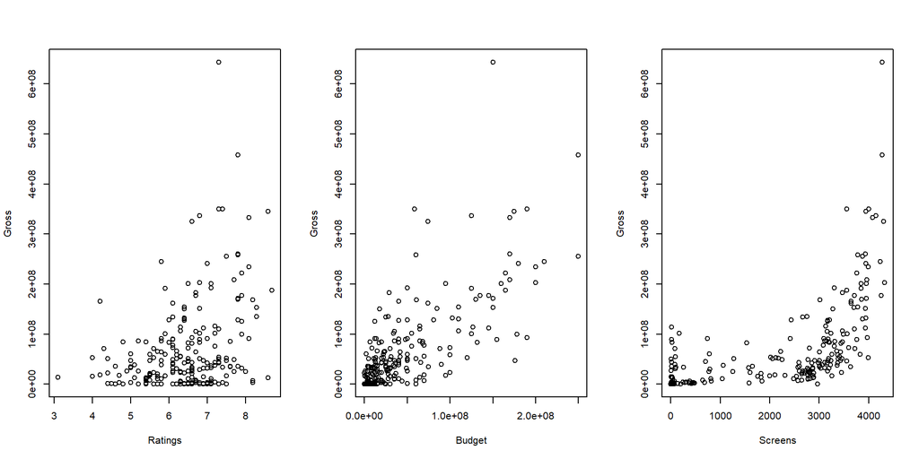

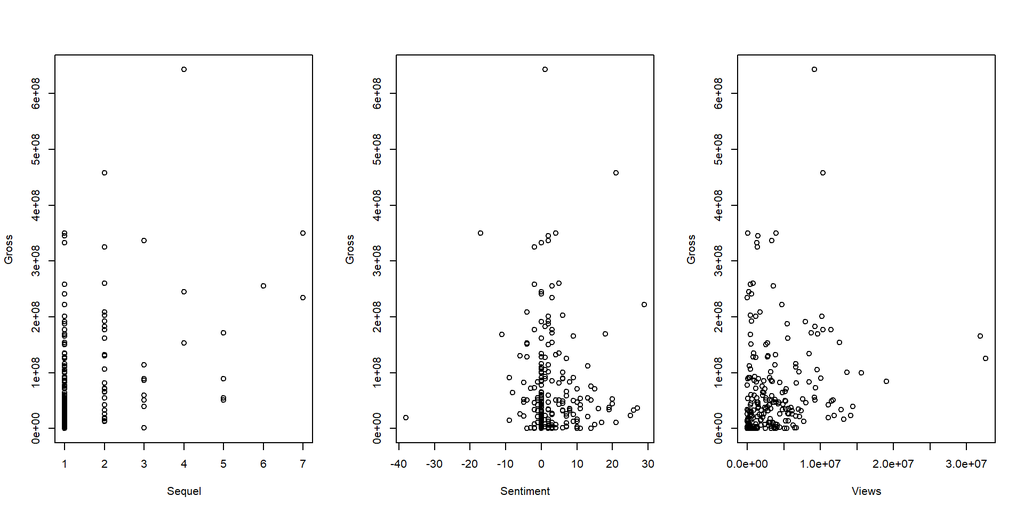

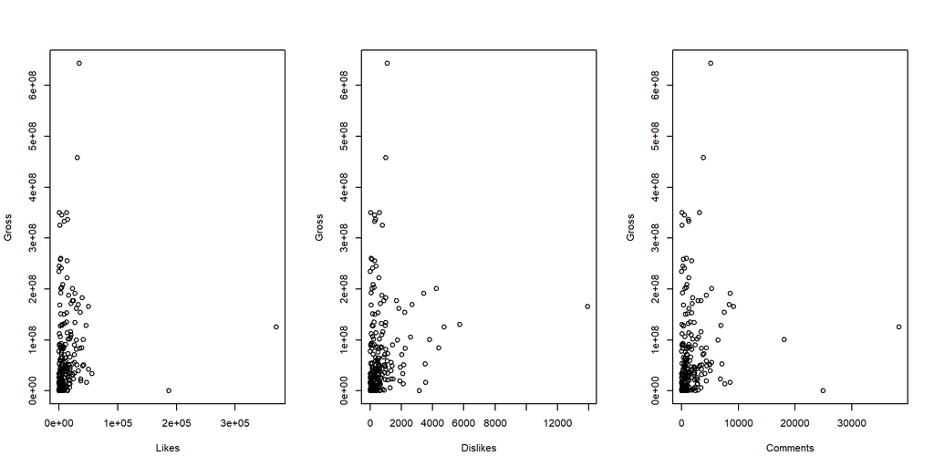

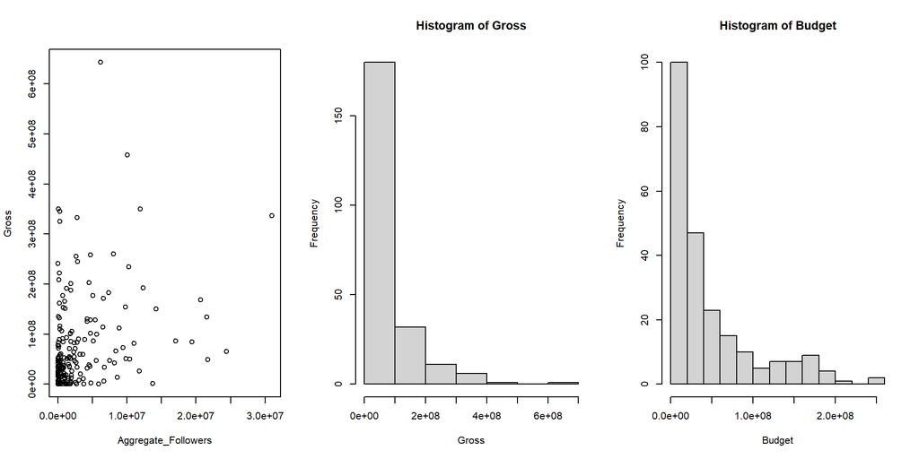

The scatter plots reveal a positive linear correlation between gross and ratings. Additionally, there appears to be a positive linear association between gross income and budget. An exponential relationship is evident between gross income and screens. The presence of distinct nonlinear relationships between certain predictor variables and the response indicates the potential necessity for future transformations on predictors in linear regression.

Also, the histogram shows we have might to do some transformation to normalize Budget and Gross.

### MODEL SELECTION AND INTERPRETATION

First we run the full model with the full predictors.

```
##
## Call:
## lm(formula = Gross ~ . - Movie, data = datamovie)
##
## Residuals:
##        Min         1Q     Median         3Q        Max
## -128947840  -32056358   -4997581   23721984  416497778
##
## Coefficients:
##                       Estimate Std. Error t value Pr(>|t|)
## (Intercept)         -1.554e+08  3.860e+07  -4.026 8.61e-05 ***
## Year2015             3.697e+06  1.120e+07   0.330  0.74174
## Ratings              2.439e+07  5.762e+06   4.234 3.79e-05 ***
## Genre2              -1.706e+07  2.108e+07  -0.809  0.41959
## Genre3              -2.401e+07  1.533e+07  -1.566  0.11921
## Genre6              -3.919e+06  4.533e+07  -0.086  0.93120
## Genre7               2.978e+07  6.321e+07   0.471  0.63811
## Genre8              -1.500e+07  1.468e+07  -1.022  0.30829
## Genre9              -1.611e+07  2.276e+07  -0.708  0.48001
## Genre10             -2.614e+07  2.347e+07  -1.114  0.26686
## Genre12             -9.465e+06  2.048e+07  -0.462  0.64451
## Genre15              1.821e+07  2.717e+07   0.670  0.50362
## Budget               6.934e-01  1.278e-01   5.424 2.03e-07 ***
## Screens              1.217e+04  4.236e+03   2.874  0.00458 **
## Sequel               8.236e+06  5.179e+06   1.590  0.11366
## Sentiment           -3.673e+05  6.680e+05  -0.550  0.58315
## Views               -2.389e+00  2.127e+00  -1.123  0.26301
## Likes                5.457e+02  4.272e+02   1.277  0.20323
## Dislikes             1.343e+04  6.308e+03   2.129  0.03473 *
## Comments            -3.191e+03  3.779e+03  -0.845  0.39959
## Aggregate_Followers  2.628e+00  9.953e-01   2.640  0.00907 **
## ---
## Signif. codes:  0 '***' 0.001 '**' 0.01 '*' 0.05 '.' 0.1 ' ' 1
##
## Residual standard error: 61030000 on 166 degrees of freedom
##   (44 observations deleted due to missingness)
## Multiple R-squared:  0.623,  Adjusted R-squared:  0.5776
## F-statistic: 13.72 on 20 and 166 DF,  p-value: < 2.2e-16
```

We can see so many predictors are insignificant if we carry out the hypothesis testing from the p-value.

We can also check for multicollinearity also to remove predictors involved if need be.

### VIF Table

```
##                         GVIF Df GVIF^(1/(2*Df))
## Year                1.293638  1        1.137382
## Ratings             1.651439  1        1.285083
## Genre               3.040520  9        1.063728
## Budget              2.660938  1        1.631238
## Screens             1.861517  1        1.364374
## Sequel              1.498031  1        1.223941
## Sentiment           1.146271  1        1.070641
## Views               5.085107  1        2.255018
## Likes               7.617109  1        2.759911
## Dislikes            3.437097  1        1.853941
## Comments            8.627002  1        2.937176
## Aggregate_Followers 1.224323  1        1.106491
```

We can check the correlation table to also see how the variables relates with another.

### Correlation Table

```
##                         Ratings      Gross       Budget     Screens      Sequel
## Ratings              1.00000000  0.3767517  0.316338081  0.10003655  0.12403103
## Gross                0.37675169  1.0000000  0.704223884  0.57256644  0.41304395
## Budget               0.31633808  0.7042239  1.000000000  0.58364937  0.45858789
## Screens              0.10003655  0.5725664  0.583649367  1.00000000  0.26557482
## Sequel               0.12403103  0.4130439  0.458587891  0.26557482  1.00000000
## Sentiment            0.12420453 -0.0417894  0.002547036 -0.05832419 -0.13629782
## Views               -0.02384453  0.1321111  0.050885826  0.20676986 -0.06209265
## Likes                0.10833935  0.1145582 -0.003656854  0.14516317 -0.04264720
## Dislikes            -0.22577069  0.1168953  0.045771597  0.23355808 -0.07413455
## Comments             0.02892495  0.1254325  0.077942374  0.18084197 -0.07858265
## Aggregate_Followers  0.07433901  0.2916578  0.158611207  0.20862340  0.22186922
##                        Sentiment       Views        Likes    Dislikes
## Ratings              0.124204529 -0.02384453  0.108339346 -0.22577069
## Gross               -0.041789401  0.13211111  0.114558154  0.11689530
## Budget               0.002547036  0.05088583 -0.003656854  0.04577160
## Screens             -0.058324187  0.20676986  0.145163173  0.23355808
## Sequel              -0.136297823 -0.06209265 -0.042647200 -0.07413455
## Sentiment            1.000000000  0.03735213  0.054893129  0.02337369
## Views                0.037352129  1.00000000  0.723141665  0.77644430
## Likes                0.054893129  0.72314166  1.000000000  0.44708774
## Dislikes             0.023373693  0.77644430  0.447087736  1.00000000
## Comments             0.051506597  0.76460462  0.903079927  0.56434218
## Aggregate_Followers -0.100993742  0.14751251  0.082523923  0.04667562
##                        Comments Aggregate_Followers
## Ratings              0.02892495          0.07433901
## Gross                0.12543254          0.29165778
## Budget               0.07794237          0.15861121
## Screens              0.18084197          0.20862340
## Sequel              -0.07858265          0.22186922
## Sentiment            0.05150660         -0.10099374
## Views                0.76460462          0.14751251
## Likes                0.90307993          0.08252392
## Dislikes             0.56434218          0.04667562
## Comments             1.00000000          0.03469723
## Aggregate_Followers  0.03469723          1.00000000
```

From the correlation table we can see a correlation among Views, Likes, Dislikes and comments. This means some of them might have to be excluded from the model but it still isn’t so clear as to what predictors to choose.

So we use the best subset regression model to check for the best model.

### Best Subset Regression

```
##                                               Best Subsets Regression
## -------------------------------------------------------------------------------------------------------------------
## Model Index    Predictors
## -------------------------------------------------------------------------------------------------------------------
##      1         Budget
##      2         Budget Screens
##      3         Ratings Budget Screens
##      4         Ratings Budget Screens Aggregate_Followers
##      5         Ratings Genre Budget Screens Aggregate_Followers
##      6         Ratings Genre Budget Screens Dislikes Aggregate_Followers
##      7         Ratings Genre Budget Screens Sequel Dislikes Aggregate_Followers
##      8         Ratings Genre Budget Screens Sequel Views Dislikes Aggregate_Followers
##      9         Ratings Genre Budget Screens Sequel Views Likes Dislikes Aggregate_Followers
##     10         Ratings Genre Budget Screens Sequel Views Likes Dislikes Comments Aggregate_Followers
##     11         Ratings Genre Budget Screens Sequel Sentiment Views Likes Dislikes Comments Aggregate_Followers
##     12         Year Ratings Genre Budget Screens Sequel Sentiment Views Likes Dislikes Comments Aggregate_Followers
## -------------------------------------------------------------------------------------------------------------------
##
##                                                            Subsets Regression Summary
## -------------------------------------------------------------------------------------------------------------------------------------------------
##                        Adj.        Pred
## Model    R-Square    R-Square    R-Square      C(p)         AIC       SBIC       SBC           MSEP            FPE             HSP          APC
## -------------------------------------------------------------------------------------------------------------------------------------------------
##   1        0.5182      0.5161      0.5036      8.6191    8909.6389      NA    8919.9532    8.815075e+17    3.865967e+15    1.688388e+13    0.4903
##   2        0.5486      0.5445      0.5313      0.6929    8514.7776      NA    8528.3521     8.10699e+17    3.735165e+15     1.70598e+13    0.4638
##   3        0.5783      0.5724      0.5586    -11.4046    8501.8355      NA    8518.8036    7.609887e+17     3.52178e+15    1.608786e+13    0.4373
##   4        0.5916      0.5826      0.5655      2.8428    7240.0295      NA    7259.4162     6.88291e+17    3.778774e+15    2.033353e+13    0.4309
##   5        0.6008      0.5708        -Inf      0.7660    7253.7417      NA    7302.2083    6.764255e+17    3.905477e+15    2.102257e+13    0.4256
##   6        0.6079      0.5759        -Inf     -0.3291    7252.4194      NA    7304.1171    6.682263e+17    3.879005e+15     2.08885e+13    0.4227
##   7        0.6165      0.5829        -Inf     -2.1372    7250.2492      NA    7305.1780    6.571607e+17    3.835311e+15    2.066272e+13    0.4178
##   8        0.6180      0.5820        -Inf     -0.7874    7251.5278      NA    7309.6877    6.583288e+17    3.862724e+15    2.082121e+13    0.4207
##   9        0.6202      0.5820        -Inf      0.2320    7252.4344      NA    7313.8255    6.582097e+17    3.882638e+15    2.094062e+13    0.4227
##  10        0.6222      0.5817        -Inf      1.3513    7253.4470      NA    7318.0691    6.584846e+17    3.904901e+15    2.107407e+13    0.4250
##  11        0.6228      0.5798        -Inf      3.1090    7255.1744      NA    7323.0277    6.613043e+17    3.942372e+15    2.129104e+13    0.4290
##  12        0.6230      0.5776        -Inf      5.0000    7257.0517      NA    7328.1361    6.646905e+17    3.983437e+15    2.152898e+13    0.4333
## -------------------------------------------------------------------------------------------------------------------------------------------------
## AIC: Akaike Information Criteria
##  SBIC: Sawa's Bayesian Information Criteria
##  SBC: Schwarz Bayesian Criteria
##  MSEP: Estimated error of prediction, assuming multivariate normality
##  FPE: Final Prediction Error
##  HSP: Hocking's Sp
##  APC: Amemiya Prediction Criteria
```

### Model According to Best Subset Regression

$$\begin{equation}
\text{$Gross = \beta_0 + \beta_1(Ratings) + \beta_2(Budget) +
\beta_3(Screens) + \beta_4(Sequel) + \beta_6(Aggregate Followers)$}
\end{equation}$$

```
##
## Call:
## lm(formula = Gross ~ Ratings + Budget + Screens + Sequel + Aggregate_Followers,
##     data = datamovie)
##
## Residuals:
##        Min         1Q     Median         3Q        Max
## -121843077  -31111884   -2654884   20002259  420436947
##
## Coefficients:
##                       Estimate Std. Error t value Pr(>|t|)
## (Intercept)         -1.349e+08  3.111e+07  -4.338 2.39e-05 ***
## Ratings              1.814e+07  4.707e+06   3.853 0.000162 ***
## Budget               7.151e-01  1.088e-01   6.575 5.05e-10 ***
## Screens              1.603e+04  3.847e+03   4.167 4.77e-05 ***
## Sequel               8.361e+06  4.781e+06   1.749 0.082008 .
## Aggregate_Followers  2.570e+00  9.250e-01   2.778 0.006050 **
## ---
## Signif. codes:  0 '***' 0.001 '**' 0.01 '*' 0.05 '.' 0.1 ' ' 1
##
## Residual standard error: 60330000 on 181 degrees of freedom
##   (44 observations deleted due to missingness)
## Multiple R-squared:  0.5983, Adjusted R-squared:  0.5873
## F-statistic: 53.93 on 5 and 181 DF,  p-value: < 2.2e-16
```

### Residual vs Fitted Values

We take a look at the Residual plot to check our linearity assumptions.

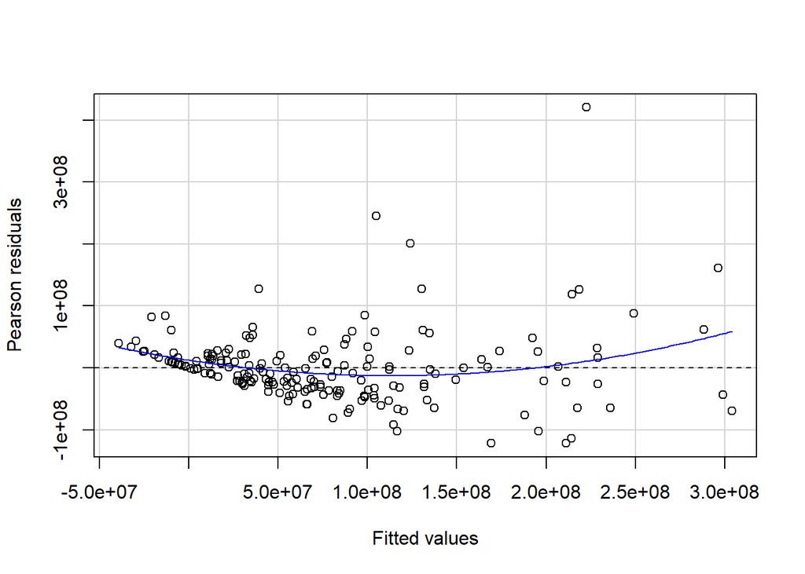

Constant Variance is violated.

Also, looking at the predictors one can see that Dislike makes sense to be a significant predictor since it means the numbers of dislikes from social media.

So we add Dislikes as a predictor in our model and see what our model looks like.

### With Dislike as a predictor our model becomes:

$$\begin{equation}
\text{$Gross = \beta_0 + \beta_1(Ratings) + \beta_2(Budget) +
\beta_3(Screens) + \beta_4(Sequel) + \beta_5(Dislikes) +
\beta_6(Aggregate Followers)$}
\end{equation}$$

```
##
## Call:
## lm(formula = Gross ~ Ratings + Budget + Screens + Sequel + Dislikes +
##     Aggregate_Followers, data = datamovie)
##
## Residuals:
##        Min         1Q     Median         3Q        Max
## -121588785  -31097669   -4070717   21142664  416956719
##
## Coefficients:
##                       Estimate Std. Error t value Pr(>|t|)
## (Intercept)         -1.514e+08  3.205e+07  -4.724 4.64e-06 ***
## Ratings              2.036e+07  4.814e+06   4.229 3.72e-05 ***
## Budget               7.123e-01  1.080e-01   6.597 4.53e-10 ***
## Screens              1.430e+04  3.924e+03   3.644 0.000351 ***
## Sequel               9.496e+06  4.782e+06   1.986 0.048581 *
## Dislikes             6.882e+03  3.583e+03   1.921 0.056373 .
## Aggregate_Followers  2.508e+00  9.188e-01   2.729 0.006976 **
## ---
## Signif. codes:  0 '***' 0.001 '**' 0.01 '*' 0.05 '.' 0.1 ' ' 1
##
## Residual standard error: 59880000 on 180 degrees of freedom
##   (44 observations deleted due to missingness)
## Multiple R-squared:  0.6064, Adjusted R-squared:  0.5933
## F-statistic: 46.22 on 6 and 180 DF,  p-value: < 2.2e-16
```

We can see that this model has a better adjusted R squared and we can now also check the residual plot.

### Residual Plot

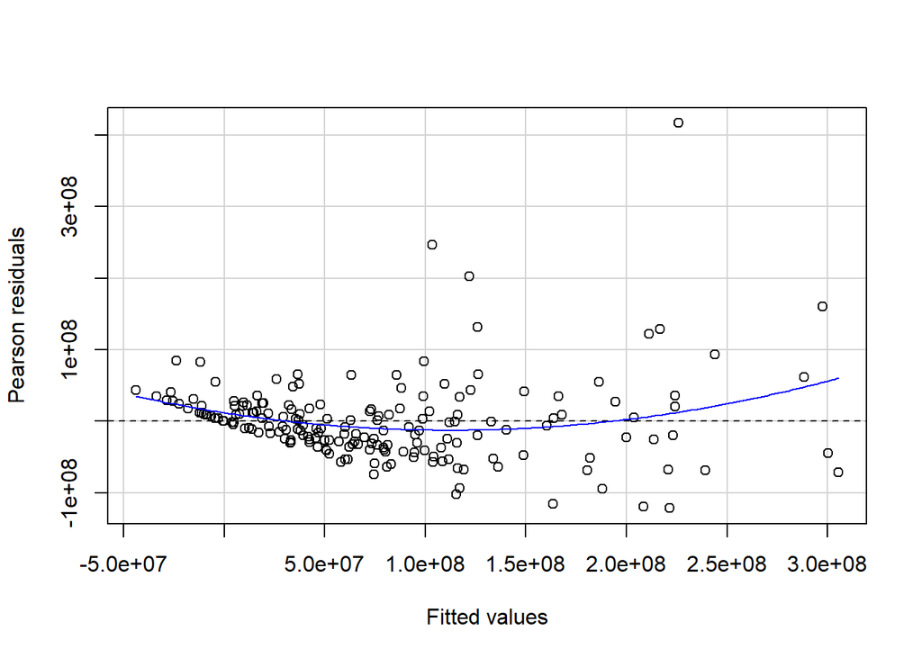

From the plot we can see that constant variance is also violated. So we try to make some adjustments and transformations on our model.

### Transformation

We can also try to explore other models,

Looking at the histograms in the Exploratory data analysis, we can tell that the we can carry out some transformation to normalize the predictors and see if it helps our models fit.

firstly, we take a look at the histograms of the Log and Square root Transforms of Gross and Budget.

### Histogram Of Transformations

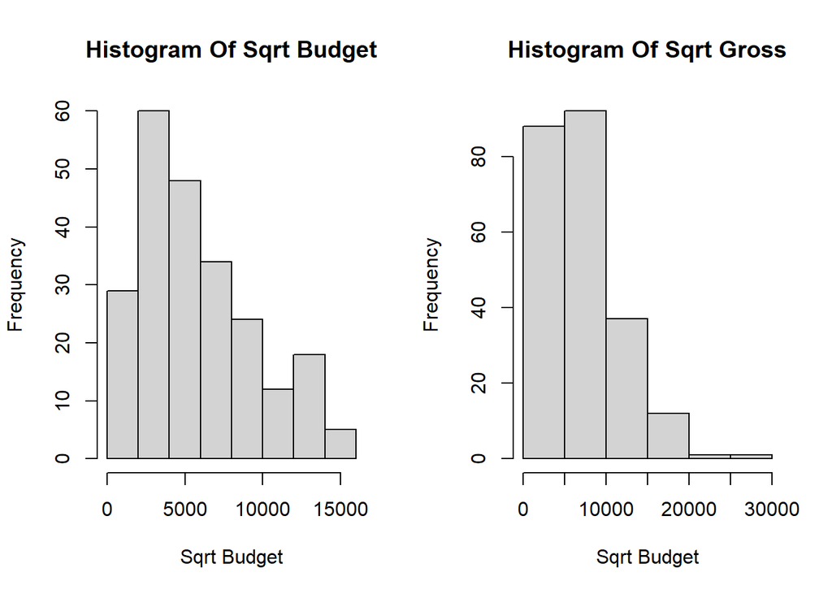

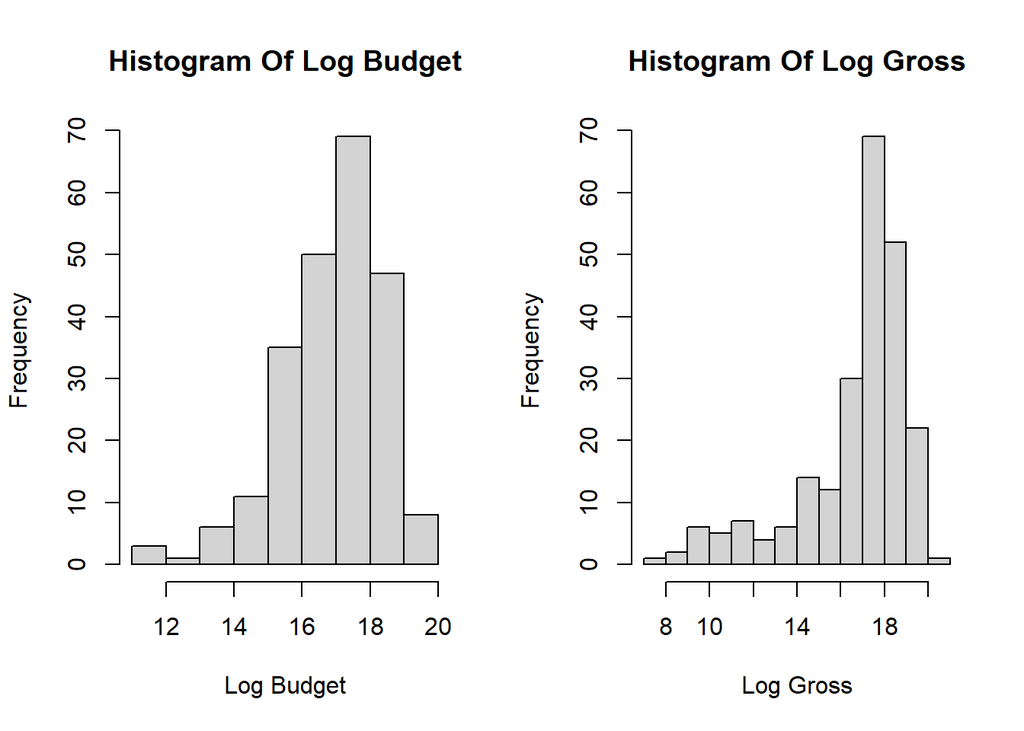

From the histograms we can see that the transformed Budget and Gross have an approximately normal distribution in its square root transformation than its logarithmic transformation.

So we can run our model again with these transformations.

### New Model with Transformation

Our new model becomes;

$$\begin{equation}
\text{$\sqrt{Gross} = \beta_0 + \beta_1(Ratings) +
\beta_2(\sqrt{Budget}) + \beta_3(Screens) + \beta_4(Sequel) +
\beta_5(Dislikes) + \beta_6(Aggregate Followers)$}
\end{equation}$$

```
##
## Call:
## lm(formula = sqrtGross ~ Ratings + sqrtBudget + Screens + Sequel +
##     Dislikes + Aggregate_Followers, data = datamovie)
##
## Residuals:
##     Min      1Q  Median      3Q     Max
## -7763.2 -1707.9  -426.5  1496.2 10217.0
##
## Coefficients:
##                       Estimate Std. Error t value Pr(>|t|)
## (Intercept)         -6.656e+03  1.384e+03  -4.808 3.21e-06 ***
## Ratings              1.074e+03  2.164e+02   4.965 1.59e-06 ***
## sqrtBudget           4.806e-01  7.756e-02   6.197 3.81e-09 ***
## Screens              1.170e+00  1.854e-01   6.311 2.09e-09 ***
## Sequel               4.561e+02  2.103e+02   2.168  0.03145 *
## Dislikes             4.335e-01  1.613e-01   2.688  0.00787 **
## Aggregate_Followers  1.257e-04  4.133e-05   3.041  0.00271 **
## ---
## Signif. codes:  0 '***' 0.001 '**' 0.01 '*' 0.05 '.' 0.1 ' ' 1
##
## Residual standard error: 2695 on 180 degrees of freedom
##   (44 observations deleted due to missingness)
## Multiple R-squared:  0.6955, Adjusted R-squared:  0.6854
## F-statistic: 68.54 on 6 and 180 DF,  p-value: < 2.2e-16
```

Therefore, after carrying out our transformation we can tell this is a better model with a better adjusted R^2. All our predictors appear to be significant. Lets also take a look at plots of this model to check if there a violations and determine if we are going to make further adjustments.

### Our Transformed Model Plots

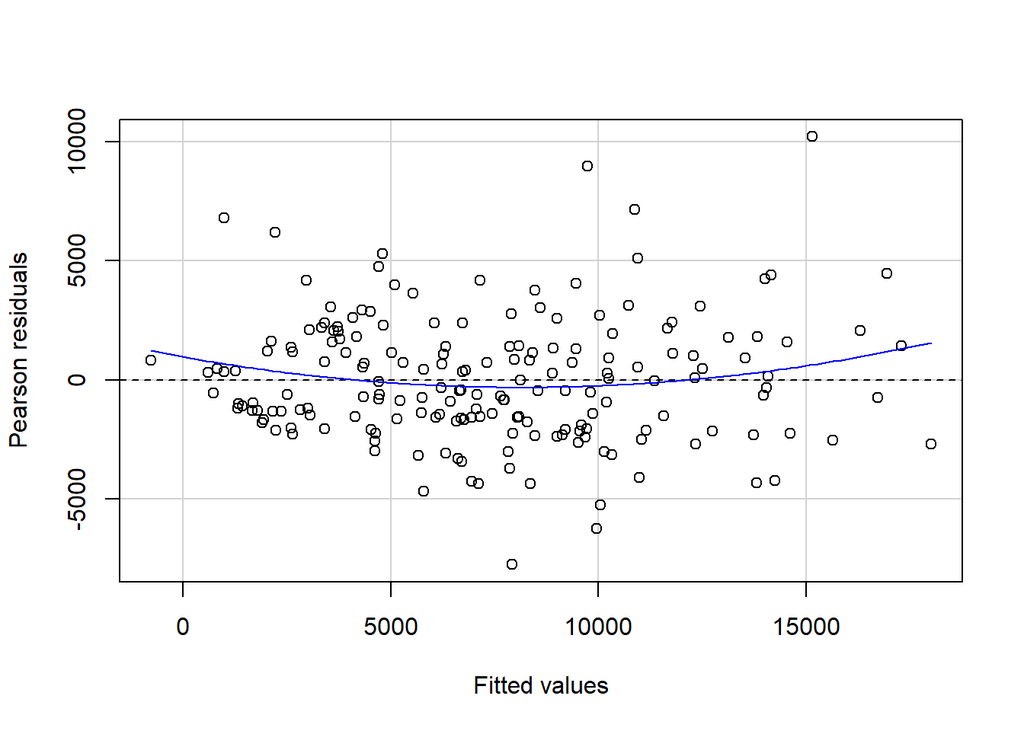

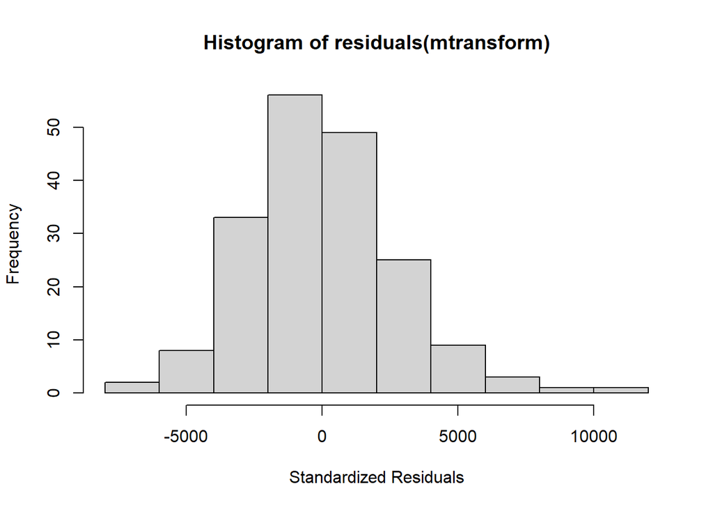

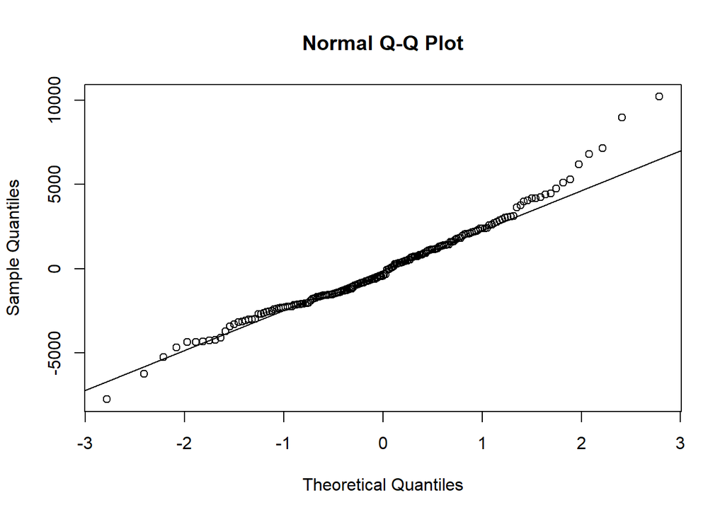

Though from the plot it appears our model still has a couple High Leverage points and Outliers but they are few as we can see below.

### High Leverage Points

```
##  13 125 128 149 162 166 172
##  12 101 104 121 132 136 142
```

### Outliers

```
##  11 164
##  10 134
```

### Recommended model

Our Recommended model will be:

$$\begin{equation}
\text{$\sqrt{Gross} = \beta_0 + \beta_1(Ratings) +
\beta_2(\sqrt{Budget}) + \beta_3(Screens) + \beta_4(Sequel) +
\beta_5(Dislikes) + \beta_6(Aggregate Followers)$}
\end{equation}$$

```
##
## Call:
## lm(formula = sqrtGross ~ Ratings + sqrtBudget + Screens + Sequel +
##     Dislikes + Aggregate_Followers, data = datamovie)
##
## Residuals:
##     Min      1Q  Median      3Q     Max
## -7763.2 -1707.9  -426.5  1496.2 10217.0
##
## Coefficients:
##                       Estimate Std. Error t value Pr(>|t|)
## (Intercept)         -6.656e+03  1.384e+03  -4.808 3.21e-06 ***
## Ratings              1.074e+03  2.164e+02   4.965 1.59e-06 ***
## sqrtBudget           4.806e-01  7.756e-02   6.197 3.81e-09 ***
## Screens              1.170e+00  1.854e-01   6.311 2.09e-09 ***
## Sequel               4.561e+02  2.103e+02   2.168  0.03145 *
## Dislikes             4.335e-01  1.613e-01   2.688  0.00787 **
## Aggregate_Followers  1.257e-04  4.133e-05   3.041  0.00271 **
## ---
## Signif. codes:  0 '***' 0.001 '**' 0.01 '*' 0.05 '.' 0.1 ' ' 1
##
## Residual standard error: 2695 on 180 degrees of freedom
##   (44 observations deleted due to missingness)
## Multiple R-squared:  0.6955, Adjusted R-squared:  0.6854
## F-statistic: 68.54 on 6 and 180 DF,  p-value: < 2.2e-16
```

Looking at the summary table the adjusted R-squared for our model is 0.6854. This indicates that 68.5% of variability in $\sqrt{Gross}$ is explained by our regression model with all the predictors collectively.

### SUMMARY

This project proves that through multi linear regression, we can predict the Gross income of a movie by using Ratings, Budget, Screens, Sequel, Dislikes and Aggregate Followers. One of the key takeaways is that though one would think that dislikes would affect our model negatively. That is the higher the dislikes the lesser the income the movie would make. But we can see that the reverse is the case according to our model. This also makes sense because if a movie as a lot of dislikes then it is likely that a lot of people have actually paid to see the movie. So the movie still rakes in a lot of money despite the fact that it was Disliked a lot on social media.

### CONCLUSION

Looking back at our prior theories, there is a Positive relationship between Numbers of Screen and Gross; proving that the more cinema screens showing the movie the more income the movie rakes in.

Also, Positive relationship between Budget and Gross, If a lot of money is spent producing a movie, it is likely going to blow up and many people will pay to see and this is also evident in our model.

Genre is not statistically significant. The genre of a movie should not be important in determining how much a movie makes. Top movies aren’t from a particular genre, they could be romantic or adventurous. This is also true.

However, we predicted that Aggregate actor followers should not be significant in predicting Gross but our model disproves this. Which also makes sense because if a movie has a lot of popular actors then a lot of people will likely see the movie because they love the actors and follow them on social media.

Also, one of our prior theories also was dislikes should have a negative relationship with Gross. This was also disproved by our model and this was explained in the summary.

### REFERENCES

Ahmed M, Jahangir M, Afzal H, Majeed A, Siddiqi I. Using Crowd-source based features from social media and Conventional features to predict the movies popularity. 2015 IEEE International Conference on 205 Dec 19 (pp. 273-278). IEEE.